# Reproducible Research: Peer Assessment 1

Yanyuan Zhu

Aug 13, 2020

## Load packages and set work directory

```r
## load packages
library(data.table)
library(ggplot2)
# Fork github url before setting wd
# set work directory
setwd("~/Soft/Rtest/RepData_PeerAssessment1")
```

## Loading and preprocessing the data

Download the source code file

```r
## Download the source code file
fileUrl <- "https://d396qusza40orc.cloudfront.net/repdata%2Fdata%2Factivity.zip"
download.file(fileUrl, destfile = "./data/repdata_data_activity.zip")
```

unzip the file in linux, then

```r
activity <- data.table::fread('./data/activity.csv')
```

## What is mean total number of steps taken per day?

Calculate the total number of steps per day

```r
#activity[, lapply(.SD, sum, na.rm = FALSE)]
total_steps <- activity[, c(lapply(.SD, sum, na.rm = FALSE))
         , .SDcols = c("steps")
         , by = .(date)
        ]
head(total_steps)
```

```
##          date steps
## 1: 2012-10-01    NA
## 2: 2012-10-02   126
## 3: 2012-10-03 11352
## 4: 2012-10-04 12116
## 5: 2012-10-05 13294
## 6: 2012-10-06 15420
```

Make a histogram of the total number of steps taken each day.

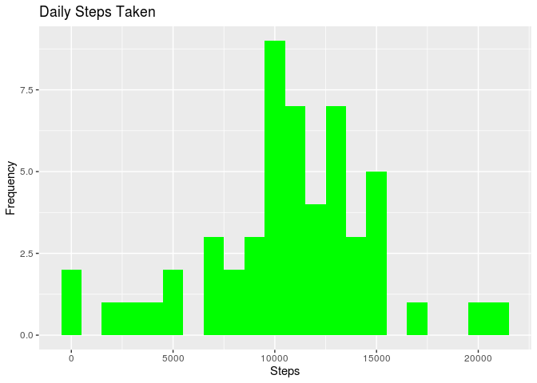

```r
g <- NULL
g <- ggplot(total_steps, aes(x = steps))
g <- g + geom_histogram(fill = 'green', binwidth = 1000)
g <- g + labs(
    title = "Daily Steps Taken"
    , x = 'Steps'
    , y = "Frequency"
)
g
```

Report mean and median values of the total number of steps taken per day

```r
total_steps[, .(Mean_steps = mean(steps, na.rm = TRUE)
               , Median_steps = median(steps, na.rm = TRUE)
               )
           ]
```

```
##    Mean_steps Median_steps
## 1:   10766.19        10765
```

## What is the average daily activity pattern?

Make a dataframe named *interval*, showing average number of steps taken everyday

```r
interval <- activity[
    , c(
        lapply(.SD, mean, na.rm = TRUE)
       )
    , .SDcols = c("steps")
    , by = .(interval)
]
head(interval)
```

```
##    interval     steps
## 1:        0 1.7169811
## 2:        5 0.3396226
## 3:       10 0.1320755
## 4:       15 0.1509434
## 5:       20 0.0754717
## 6:       25 2.0943396
```

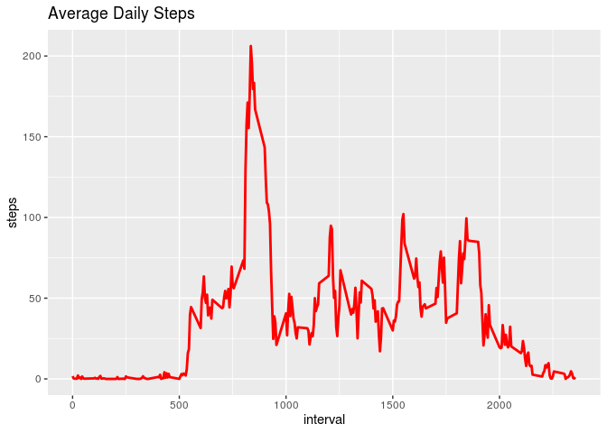

```r
g <- ggplot(interval, aes(x = interval, y = steps))
g <- g + geom_line(color = 'red', size = 1)
g <- g + labs(
    title = "Average Daily Steps"
    , xlab = 'Interval'
    , ylab = "Average Steps Per Day"
)
g
```

Which 5-minute interval, on average across all the days in the dataset, contains the maximum number of steps?

```r
interval[steps == max(steps), .(max_interval = interval)]
```

```
##    max_interval
## 1:          835
```

## Imputing missing values

Check number of NAs in the column steps

```r
#activity[is.na(steps), .N]
nrow(activity[is.na(steps), ])
```

```
## [1] 2304
```

Replace NAs with median values

```r
#activity[is.na(steps), "steps"] <-
activity[is.na(steps), 'steps'] <- activity[, c(lapply(.SD, median, na.rm=TRUE))
                                             , .SDcols = c("steps")
                                            ]
```

Export a tidy dataset with missing value filled

```r
data.table::fwrite(x = activity, file = './data/tidyData.txt', quote = FALSE)
```

Total number of steps taken per day

```r
# total number of steps taken per day
total_steps <- activity[, c(lapply(.SD, sum)), .SDcols = c("steps"), by = .(date)]
head(total_steps)
```

```
##          date steps
## 1: 2012-10-01     0
## 2: 2012-10-02   126
## 3: 2012-10-03 11352
## 4: 2012-10-04 12116
## 5: 2012-10-05 13294
## 6: 2012-10-06 15420
```

Mean and median total number of steps taken per day

```r
# mean and median total number of steps taken per day
total_steps[, .(mean_steps = mean(steps), median_steps = median(steps))]
```

```
##    mean_steps median_steps
## 1:    9354.23        10395
```

Make the plot

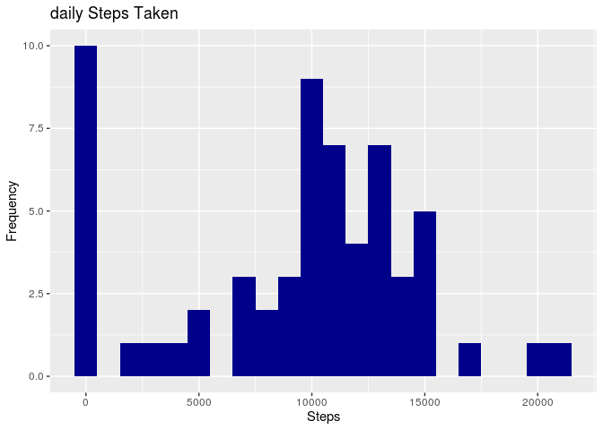

```r
g <- NULL
g <- ggplot(total_steps, aes(x = steps))
g <- g + geom_histogram(fill = "darkblue", binwidth = 1000)
g <- g + labs(
    title = "daily Steps Taken"
    , x = "Steps"
    , y = "Frequency"
)
g
```

## Are there differences in activity patterns between weekdays and weekends?

Create a new factor column with 2 levels: weekday and weekend

```r
# create a new factor column with 2 levels: weekday and weekend
activity <- fread(input = './data/activity.csv')
activity[, date := as.POSIXct(date, format = "%Y-%m-%d")]
activity$"Day_of_Week" = weekdays(activity$date)
```

Create a new column, indicating whether the day is weekday (Monday to Friday) or weekend (Saturday, Sunday)

```r
activity [grepl(pattern = "星期一|星期二|星期三|星期四|星期五", x = activity$'Day_of_Week'), "Weekday_or_Weekend"] <- "Weekday"
activity [grepl(pattern = "星期六|星期日", x = activity$'Day_of_Week'), "Weekday_or_Weekend"] <- "Weekend"
```

Check the dataframe

```r
str(activity)
```

```
## Classes 'data.table' and 'data.frame':   17568 obs. of  5 variables:
##  $ steps             : int  NA NA NA NA NA NA NA NA NA NA ...
##  $ date              : POSIXct, format: "2012-10-01" "2012-10-01" ...
##  $ interval          : int  0 5 10 15 20 25 30 35 40 45 ...
##  $ Day_of_Week       : chr  "星期一" "星期一" "星期一" "星期一" ...
##  $ Weekday_or_Weekend: chr  "Weekday" "Weekday" "Weekday" "Weekday" ...
##  - attr(*, ".internal.selfref")=<externalptr>
```

Replace missing values in "steps" column by median value

```r
# Replace missing values in "steps" column by median value
activity[is.na(steps), 'steps'] <- median(activity$steps, na.rm = TRUE)
```

```r
# Create a new dataframe, replace missing values in "steps" column by mean value, by interval and "Weekday or Weekend"
interval_df <- activity[, c(lapply(.SD, mean, na.rm = TRUE)), .SDcols = c("steps"), by = .(interval, `Weekday_or_Weekend`)]
#interval_df$"Weekday_or_Weekend" <- as.factor(interval_df$"Weekday_or_Weekend")
interval_df$Weekday_or_Weekend <- as.factor(interval_df$Weekday_or_Weekend)
```

```r
str(interval_df)
```

```
## Classes 'data.table' and 'data.frame':   576 obs. of  3 variables:
##  $ interval          : int  0 5 10 15 20 25 30 35 40 45 ...
##  $ Weekday_or_Weekend: Factor w/ 2 levels "Weekday","Weekend": 1 1 1 1 1 1 1 1 1 1 ...
##  $ steps             : num  2.0222 0.4 0.1556 0.1778 0.0889 ...
##  - attr(*, ".internal.selfref")=<externalptr>
```

Make a panel plot containing a time series plot (i.e. 𝚝𝚢𝚙𝚎 = "𝚕") of the 5-minute interval (x-axis) and the average number of steps taken, averaged across all weekday days or weekend days (y-axis). See the README file in the GitHub repository to see an example of what this plot should look like using simulated data.

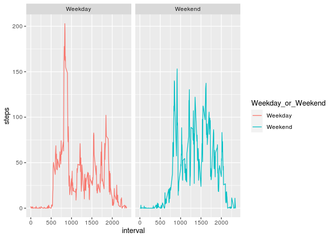

```r
g <- NULL
g <- ggplot(interval_df, aes(x = interval, y = steps, color = Weekday_or_Weekend))
g <- g + geom_line()
g <- g + facet_wrap(~Weekday_or_Weekend, nrow = 1, ncol=2)
g
```